# 02_T-Test Practice

A research study was conducted to examine the differences between older and younger adults on perceived life satisfaction. A pilot study was conducted to examine this hypothesis. Ten older adults (over the age of 70) and ten younger adults (between 20 and 30) were give a life satisfaction test (known to have high reliability and validity). Scores on the measure range from 0 to 60 with high scores indicative of high life satisfaction; low scores indicative of low life satisfaction. The data are presented below. Compute the appropriate t-test.

-- Độ thỏa mãn từ : 0 - 60. Với 60 được xem là độ thỏa mãn cao nhất.

```python
import pandas as pd
import numpy as np
from scipy import stats
```

```python
# Data
older   = [45, 38, 52, 48, 25, 39, 51, 46, 55, 46]
younger = [34, 22, 15, 27, 37, 41, 24, 19, 26, 36]
```

```python
# Step 1: Tinh cac gia tri Means, Variance and Standard Deviation
data = pd.DataFrame([older, younger]).transpose()
data.rename(columns={0: 'older', 1:'younger'}, inplace=True)

print('Mean : ')
print(data.mean())

print('Varience : ')
print(data.var())

print('Standard Deviation')
print(data.std())
```

```
Mean :
older      44.5
younger    28.1
dtype: float64
Varience :
older      75.388889
younger    72.988889
dtype: float64
Standard Deviation
older      8.682678
younger    8.543353
dtype: float64
```

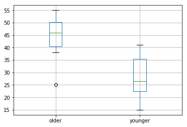

```python
# Step 2 :

# 2.1 Ve biểu đồ phân bổ 2 Group
data.boxplot()
```

## Định nghĩa Hypothesis và Null Hypothesis

### Hypothesis : Có mỗi liên hệ giữa độ tuổi và mức độ hài lòng cuộc sống

### Null hypothesis : Không có mỗi liên hệ giữa độ tuổi và mức độ hài lòng cuộc sống

```python
# Step 3: Check is normal distribute
stats.normaltest(data['older'])
stats.normaltest(data['younger'])
```

```
NormaltestResult(statistic=0.9410848911206685, pvalue=0.6246633305130271)
```

```python
# Step 4 : Tinh gia tri T-Test
stats.ttest_ind(older, younger)
```

```
Ttest_indResult(statistic=4.257546665558161, pvalue=0.0004736633119019225)
```